# FinalExam-2802501416-LunaAlexa

Luna ALexa

2025-06-21

Video Explanation Link: https://drive.google.com/drive/folders/1UgjSqnMF1EWupk0AkvnjzE0vbl_4_4kc?usp=sharing

# Bank’s Recent Marketing Campaigns Performance Evaluation

## CASE STUDY 1 - Data Quality Assessment and Preprocessing

### a. Identify data quality issues

```
##        X             age            job              marital
##  Min.   :   0   Min.   :17.00   Length:8238        Length:8238
##  1st Qu.:2059   1st Qu.:32.00   Class :character   Class :character
##  Median :4118   Median :38.00   Mode  :character   Mode  :character
##  Mean   :4118   Mean   :39.93
##  3rd Qu.:6178   3rd Qu.:47.00
##  Max.   :8237   Max.   :89.00
##
##   education           default            housing              loan
##  Length:8238        Length:8238        Length:8238        Length:8238
##  Class :character   Class :character   Class :character   Class :character
##  Mode  :character   Mode  :character   Mode  :character   Mode  :character
##
##
##
##
##    contact             month           day_of_week           duration
##  Length:8238        Length:8238        Length:8238        Min.   :   4.0
##  Class :character   Class :character   Class :character   1st Qu.: 102.0
##  Mode  :character   Mode  :character   Mode  :character   Median : 180.0
##                                                           Mean   : 258.2
##                                                           3rd Qu.: 319.8
##                                                           Max.   :4918.0
##                                                           NA's   :12
##     campaign          pdays          previous        poutcome
##  Min.   : 1.000   Min.   :  0.0   Min.   :0.0000   Length:8238
##  1st Qu.: 1.000   1st Qu.:999.0   1st Qu.:0.0000   Class :character
##  Median : 2.000   Median :999.0   Median :0.0000   Mode  :character
##  Mean   : 2.565   Mean   :963.9   Mean   :0.1697
##  3rd Qu.: 3.000   3rd Qu.:999.0   3rd Qu.:0.0000
##  Max.   :43.000   Max.   :999.0   Max.   :6.0000
##
##       y
##  Length:8238
##  Class :character
##  Mode  :character
##
##
##
##
```

```
##           X         age         job     marital   education     default
##           0           0           0           0           0           0
##     housing        loan     contact       month day_of_week    duration
##           0           0           0           0           0          12
##    campaign       pdays    previous    poutcome           y
##           0           0           0           0           0
```

From the summary, it can be seen that there is a missing value in the variable duration

```
##              job    n
## 1                   8
## 2         admin. 2033
## 3    blue-collar 1870
## 4   entrepreneur  294
## 5      housemaid  219
## 6     management  546
## 7        retired  366
## 8  self-employed  263
## 9       services  822
## 10       student  184
## 11    technician 1372
## 12    unemployed  196
## 13       unknown   65
```

```
##    marital    n
## 1 divorced  892
## 2  married 4994
## 3   single 2338
## 4  unknown   14
```

```
##             education    n
## 1            basic.4y  817
## 2            basic.6y  486
## 3            basic.9y 1243
## 4         high.school 1915
## 5          illiterate    6
## 6 professional.course 1043
## 7   university.degree 2379
## 8             unknown  349
```

```
##   default    n
## 1      no 6491
## 2 unknown 1747
```

```
##   housing    n
## 1      no 3749
## 2 unknown  205
## 3     yes 4284
```

```
##      loan    n
## 1      no 6741
## 2 unknown  205
## 3     yes 1292
```

```
##     contact    n
## 1  cellular 5232
## 2 telephone 3006
```

```
##    month    n
## 1    apr  529
## 2    aug 1189
## 3    dec   38
## 4    jul 1481
## 5    jun 1074
## 6    mar  105
## 7    may 2729
## 8    nov  827
## 9    oct  149
## 10   sep  117
```

```
##   day_of_week    n
## 1         fri 1524
## 2         mon 1676
## 3         thu 1769
## 4         tue 1599
## 5         wed 1670
```

```
##      poutcome    n
## 1     failure  836
## 2 nonexistent 7136
## 3     success  266
```

```
##     y    n
## 1  no 7329
## 2 yes  909
```

```
## [1] 0
```

There is no duplicated data

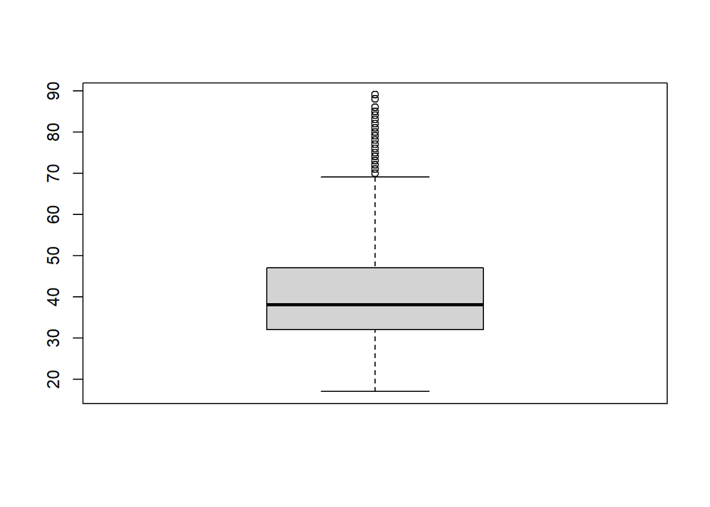

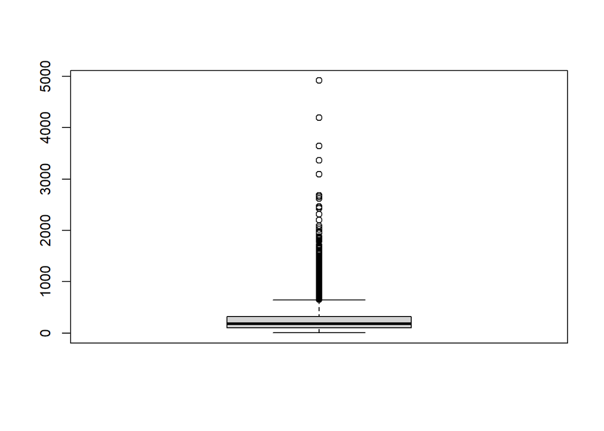

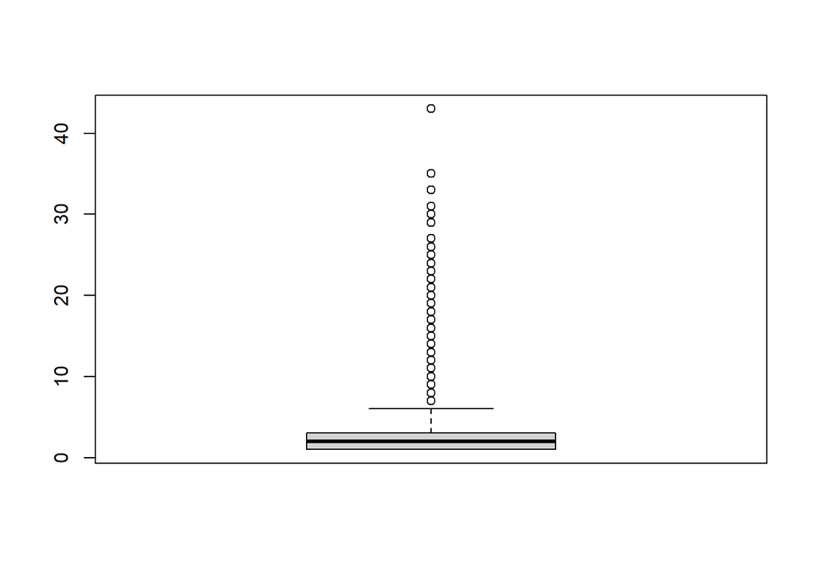

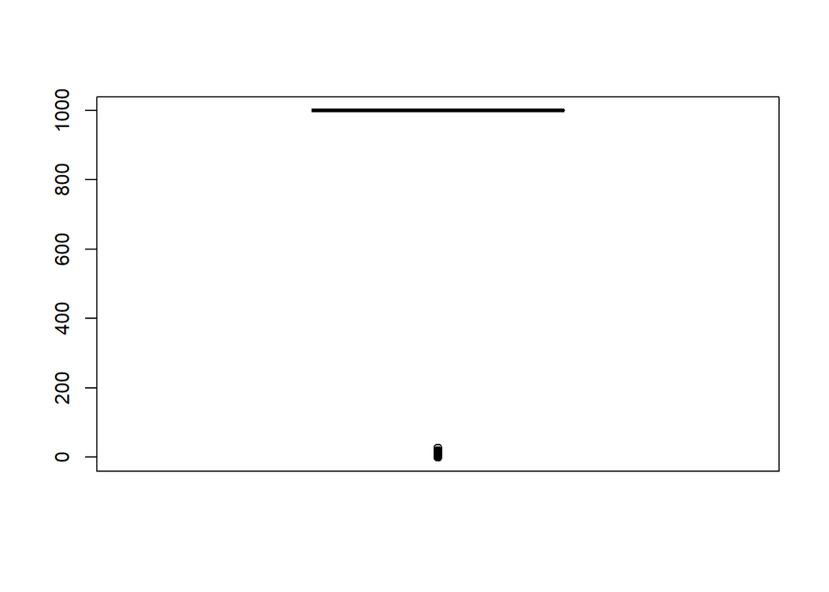

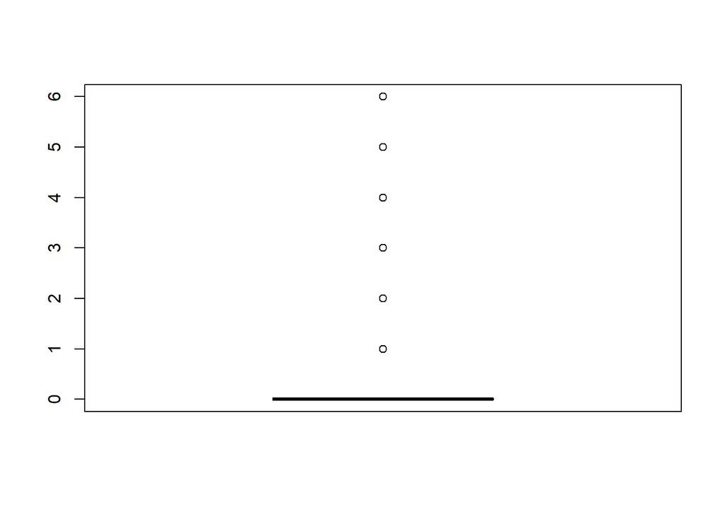

All of the numerical data have outliers

```
##
##    0    1    2    3    4    5    6    7    8    9   10   11   12   13   14   15
##    4    4   13   87   29    7   97   11    1    7    7    1    4    7    4    4
##   17   19   25   26  999
##    1    1    1    1 7947
```

Value 999 in pdays which means “not previously contacted” need to be recoded

summary :  
Missing value : duration  
Duplicate records : -  
Inconsistent or unknown categories : job, marital, education, default, housing,loan  
Outliers or extreme values : age, duration, campaign, previous  
Noisy or irrelevant values : pdays, index column(x)

### b. Handle the issues that has been identified

#### 1. Handling missing value for variable duration (Imputed)

The ‘duration’ column has missing values. Given its importance as a predictor and the skewed nature of its distribution,missing values in ‘duration’ will be imputed with the value of its median (The code below will also shows that ‘duration’ has outliers, so it needs to be imputed using median, not mean).

```
##    Min. 1st Qu.  Median    Mean 3rd Qu.    Max.    NA's
##     4.0   102.0   180.0   258.2   319.8  4918.0      12
```

```
##      25%
## -224.625
```

```
##     75%
## 646.375
```

The max value (4918.0) is much larger than Q3 (319.8) or its upper bond limit (646.375), which means there is an outlier in the duration variable, so the median must be used to replace the missing value.

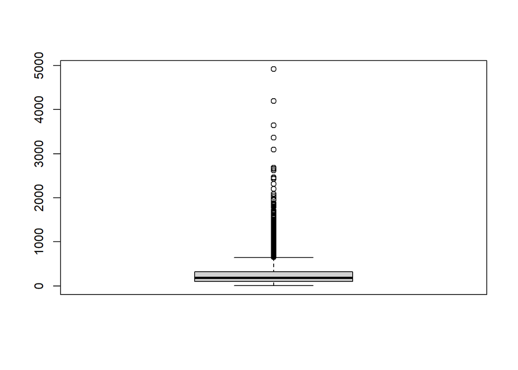

It also shows high outliers from the boxplot

```
## [1] 180
```

```
##           X         age         job     marital   education     default
##           0           0           0           0           0           0
##     housing        loan     contact       month day_of_week    duration
##           0           0           0           0           0           0
##    campaign       pdays    previous    poutcome           y
##           0           0           0           0           0
```

```
##    Min. 1st Qu.  Median    Mean 3rd Qu.    Max.
##     4.0   102.0   180.0   258.1   319.0  4918.0
```

There is no more missing value in the ‘duration’ since it is already imputed with its median

#### 2. Inconsistent or unknown categories (Imputed & recoded)

Several categorical columns contain ‘unknown’ or blank (““) values. These will be handled based on their specific characteristics. Since removing these rows would lead to significant data loss, the chosen strategy is to impute them with the mode or to recode them to preserve the dataset’s integrity.

##### Part A: Impute general categorical columns with their mode.

These columns (job, marital, education, housing, and loan) have well-distributed categories where mode imputation is a safe choice.

```
##              job    n
## 1         admin. 2106
## 2    blue-collar 1870
## 3   entrepreneur  294
## 4      housemaid  219
## 5     management  546
## 6        retired  366
## 7  self-employed  263
## 8       services  822
## 9        student  184
## 10    technician 1372
## 11    unemployed  196
```

```
##    marital    n
## 1 divorced  892
## 2  married 5008
## 3   single 2338
```

```
##             education    n
## 1            basic.4y  817
## 2            basic.6y  486
## 3            basic.9y 1243
## 4         high.school 1915
## 5          illiterate    6
## 6 professional.course 1043
## 7   university.degree 2728
```

```
##   default    n
## 1      no 6491
## 2 unknown 1747
```

```
##   housing    n
## 1      no 3749
## 2     yes 4489
```

```
##   loan    n
## 1   no 6946
## 2  yes 1292
```

```
##     contact    n
## 1  cellular 5232
## 2 telephone 3006
```

```
##    month    n
## 1    apr  529
## 2    aug 1189
## 3    dec   38
## 4    jul 1481
## 5    jun 1074
## 6    mar  105
## 7    may 2729
## 8    nov  827
## 9    oct  149
## 10   sep  117
```

```
##   day_of_week    n
## 1         fri 1524
## 2         mon 1676
## 3         thu 1769
## 4         tue 1599
## 5         wed 1670
```

```
##      poutcome    n
## 1     failure  836
## 2 nonexistent 7136
## 3     success  266
```

```
##     y    n
## 1  no 7329
## 2 yes  909
```

##### Part B: Recode the ‘default’ column.

Since this column only contains ‘no’ and ‘unknown’, it needs to be recoded to capture this specific information. This would be better if it is changed to a binary variable indicating whether the status(Whether the client has a credit in default) is known or not.

```
##              job    n
## 1         admin. 2106
## 2    blue-collar 1870
## 3   entrepreneur  294
## 4      housemaid  219
## 5     management  546
## 6        retired  366
## 7  self-employed  263
## 8       services  822
## 9        student  184
## 10    technician 1372
## 11    unemployed  196
```

```
##    marital    n
## 1 divorced  892
## 2  married 5008
## 3   single 2338
```

```
##             education    n
## 1            basic.4y  817
## 2            basic.6y  486
## 3            basic.9y 1243
## 4         high.school 1915
## 5          illiterate    6
## 6 professional.course 1043
## 7   university.degree 2728
```

```
##   knownInDefault    n
## 1             no 1747
## 2            yes 6491
```

```
##   housing    n
## 1      no 3749
## 2     yes 4489
```

```
##   loan    n
## 1   no 6946
## 2  yes 1292
```

```
##     contact    n
## 1  cellular 5232
## 2 telephone 3006
```

```
##    month    n
## 1    apr  529
## 2    aug 1189
## 3    dec   38
## 4    jul 1481
## 5    jun 1074
## 6    mar  105
## 7    may 2729
## 8    nov  827
## 9    oct  149
## 10   sep  117
```

```
##   day_of_week    n
## 1         fri 1524
## 2         mon 1676
## 3         thu 1769
## 4         tue 1599
## 5         wed 1670
```

```
##      poutcome    n
## 1     failure  836
## 2 nonexistent 7136
## 3     success  266
```

```
##     y    n
## 1  no 7329
## 2 yes  909
```

#### 3. Outliers or extreme values (Recoded/capped)

To handle outliers, capping is the most balanced option. It reduces the negative impact of the very extreme values in the variable : campaign, previous, and duration without having to discard observations. For age, outliers were retained because values such as 80 or 90 years old, while statistically extreme, are demographically plausible and represent a real segment of the client base. I will limit values at the 99th percentile. This means that any value in the top 1% will be equated to a value at the 99th percentile.

```
##        X             age                 job           marital
##  Min.   :   0   Min.   :17.00   admin.     :2106   divorced: 892
##  1st Qu.:2059   1st Qu.:32.00   blue-collar:1870   married :5008
##  Median :4118   Median :38.00   technician :1372   single  :2338
##  Mean   :4118   Mean   :39.93   services   : 822
##  3rd Qu.:6178   3rd Qu.:47.00   management : 546
##  Max.   :8237   Max.   :89.00   retired    : 366
##                                 (Other)    :1156
##                education    housing     loan        contact
##  basic.4y           : 817   no :3749   no :6946   Length:8238
##  basic.6y           : 486   yes:4489   yes:1292   Class :character
##  basic.9y           :1243                         Mode  :character
##  high.school        :1915
##  illiterate         :   6
##  professional.course:1043
##  university.degree  :2728
##     month           day_of_week           duration       campaign
##  Length:8238        Length:8238        Min.   :   4   Min.   : 1.000
##  Class :character   Class :character   1st Qu.: 102   1st Qu.: 1.000
##  Mode  :character   Mode  :character   Median : 180   Median : 2.000
##                                        Mean   : 253   Mean   : 2.507
##                                        3rd Qu.: 319   3rd Qu.: 3.000
##                                        Max.   :1275   Max.   :15.000
##
##      pdays          previous        poutcome              y
##  Min.   :  0.0   Min.   :0.0000   Length:8238        Length:8238
##  1st Qu.:999.0   1st Qu.:0.0000   Class :character   Class :character
##  Median :999.0   Median :0.0000   Mode  :character   Mode  :character
##  Mean   :963.9   Mean   :0.1595
##  3rd Qu.:999.0   3rd Qu.:0.0000
##  Max.   :999.0   Max.   :2.0000
##
##  knownInDefault
##  no :1747
##  yes:6491
##
##
##
##
##
```

#### 4. Noisy or irrelevant values (removed/recoded)

##### Part A: Remove the irrelevant ‘X’ column.

```
##       age                 job           marital                   education
##  Min.   :17.00   admin.     :2106   divorced: 892   basic.4y           : 817
##  1st Qu.:32.00   blue-collar:1870   married :5008   basic.6y           : 486
##  Median :38.00   technician :1372   single  :2338   basic.9y           :1243
##  Mean   :39.93   services   : 822                   high.school        :1915
##  3rd Qu.:47.00   management : 546                   illiterate         :   6
##  Max.   :89.00   retired    : 366                   professional.course:1043
##                  (Other)    :1156                   university.degree  :2728
##  housing     loan        contact             month           day_of_week
##  no :3749   no :6946   Length:8238        Length:8238        Length:8238
##  yes:4489   yes:1292   Class :character   Class :character   Class :character
##                        Mode  :character   Mode  :character   Mode  :character
##
##
##
##
##     duration       campaign          pdays          previous
##  Min.   :   4   Min.   : 1.000   Min.   :  0.0   Min.   :0.0000
##  1st Qu.: 102   1st Qu.: 1.000   1st Qu.:999.0   1st Qu.:0.0000
##  Median : 180   Median : 2.000   Median :999.0   Median :0.0000
##  Mean   : 253   Mean   : 2.507   Mean   :963.9   Mean   :0.1595
##  3rd Qu.: 319   3rd Qu.: 3.000   3rd Qu.:999.0   3rd Qu.:0.0000
##  Max.   :1275   Max.   :15.000   Max.   :999.0   Max.   :2.0000
##
##    poutcome              y             knownInDefault
##  Length:8238        Length:8238        no :1747
##  Class :character   Class :character   yes:6491
##  Mode  :character   Mode  :character
##
##
##
##
```

##### Part B: Recode the ‘pdays’ column.

The value 999 in pdays is a code for ‘not previously contacted’. Treating this as a numerical value would severely skew any statistical analysis. Therefore, it was recoded into a meaningful binary variable contacted_previously to accurately represent this information.

```
##
##    0    1    2    3    4    5    6    7    8    9   10   11   12   13   14   15
##    4    4   13   87   29    7   97   11    1    7    7    1    4    7    4    4
##   17   19   25   26  999
##    1    1    1    1 7947
```

```
##
##   no  yes
## 7947  291
```

```
##       age                 job           marital                   education
##  Min.   :17.00   admin.     :2106   divorced: 892   basic.4y           : 817
##  1st Qu.:32.00   blue-collar:1870   married :5008   basic.6y           : 486
##  Median :38.00   technician :1372   single  :2338   basic.9y           :1243
##  Mean   :39.93   services   : 822                   high.school        :1915
##  3rd Qu.:47.00   management : 546                   illiterate         :   6
##  Max.   :89.00   retired    : 366                   professional.course:1043
##                  (Other)    :1156                   university.degree  :2728
##  housing     loan        contact             month           day_of_week
##  no :3749   no :6946   Length:8238        Length:8238        Length:8238
##  yes:4489   yes:1292   Class :character   Class :character   Class :character
##                        Mode  :character   Mode  :character   Mode  :character
##
##
##
##
##     duration       campaign         previous        poutcome
##  Min.   :   4   Min.   : 1.000   Min.   :0.0000   Length:8238
##  1st Qu.: 102   1st Qu.: 1.000   1st Qu.:0.0000   Class :character
##  Median : 180   Median : 2.000   Median :0.0000   Mode  :character
##  Mean   : 253   Mean   : 2.507   Mean   :0.1595
##  3rd Qu.: 319   3rd Qu.: 3.000   3rd Qu.:0.0000
##  Max.   :1275   Max.   :15.000   Max.   :2.0000
##
##       y             knownInDefault contacted_previously
##  Length:8238        no :1747       no :7947
##  Class :character   yes:6491       yes: 291
##  Mode  :character
##
##
##
##
```

### c. Summary statistics and initial exploration

#### 1. Calculate central tendency and variability for numerical columns

```
##
## -Summary Statistics for Each Numerical Column-
```

```
##       age           duration       campaign         previous
##  Min.   :17.00   Min.   :   4   Min.   : 1.000   Min.   :0.0000
##  1st Qu.:32.00   1st Qu.: 102   1st Qu.: 1.000   1st Qu.:0.0000
##  Median :38.00   Median : 180   Median : 2.000   Median :0.0000
##  Mean   :39.93   Mean   : 253   Mean   : 2.507   Mean   :0.1595
##  3rd Qu.:47.00   3rd Qu.: 319   3rd Qu.: 3.000   3rd Qu.:0.0000
##  Max.   :89.00   Max.   :1275   Max.   :15.000   Max.   :2.0000
```

IQR of age : 15  
IQR of duration : 217  
IQR of campaign : 2.000  
IQR of previous : 0

```
##
## -Standard Deviation for Each Numerical Column-
```

```
##         age    duration    campaign    previous
##  10.5125206 232.3472864   2.3787102   0.4307601
```

Analysis : The summary statistics show the central tendency and spread for each numerical variable. For instance, the median client age is 38 years. The capping of outliers is evident in the Max. values for duration, campaign, and previous, which are now more reasonable.

#### 2. Create a summary table to explore one variable across categories

Summary Statistics of Age Across Different Job Types

| job | count | mean_age | median_age | sd_age | min_age | max_age |
| --- | --- | --- | --- | --- | --- | --- |
| retired | 366 | 61.8 | 59 | 10.5 | 26 | 89 |
| housemaid | 219 | 45.8 | 45 | 10.6 | 23 | 82 |
| management | 546 | 42.4 | 41 | 9.3 | 23 | 77 |
| entrepreneur | 294 | 40.7 | 39 | 9.0 | 20 | 60 |
| self-employed | 263 | 39.9 | 39 | 9.4 | 23 | 60 |
| unemployed | 196 | 39.8 | 39 | 8.9 | 23 | 66 |
| blue-collar | 1870 | 39.3 | 38 | 9.0 | 20 | 80 |
| technician | 1372 | 38.4 | 36 | 8.5 | 22 | 70 |
| admin. | 2106 | 38.4 | 36 | 9.1 | 21 | 70 |
| services | 822 | 37.6 | 36 | 9.3 | 20 | 60 |
| student | 184 | 26.0 | 26 | 4.9 | 17 | 44 |

The summary table reveals clear demographic patterns across different professions. As expected, the **“retired”** client group has the highest average age at 61.8 years, while the **“student”** group is the youngest with an average age of 26.0 years. Most other professional roles, such as **“admin.”, “technician”, and “management”**, have a median age clustered in the late 30s to early 40s, aligning with the overall median age of the entire client base. This initial exploration confirms that the data is logical and provides a solid foundation for segmenting clients based on their life stage and profession.

## CASE STUDY 2 - Relationship Analysis

### a. Explore variable relationships

To identify factors influencing the campaign outcome (y), the three key variables are : poutcome (categorical), contact (categorical), and duration (numerical). Appropriate methods are used to analyze their relationship with the outcome variable y.

#### 1. duration vs y

| y | Client Count | Mean Duration (s) | Median Duration (s) |
| --- | --- | --- | --- |
| no | 7329 | 219 | 165 |
| yes | 909 | 524 | 439 |

Observation : A powerful relationship is evident. The median call duration for clients who subscribed (yes) is 439 seconds, more than 2.5 times longer than the median for those who did not (no) at 165 seconds. This strongly indicates that longer, more engaging conversations are highly correlated with a positive campaign outcome.

#### 2. poutcome vs y

```
##
##                 no  yes
##   failure      728  108
##   nonexistent 6503  633
##   success       98  168
```

```
##
##  Pearson's Chi-squared test
##
## data:  t1
## X-squared = 773.24, df = 2, p-value < 2.2e-16
```

|  | no | yes |
| --- | --- | --- |
| failure | 87.1 | 12.9 |
| nonexistent | 91.1 | 8.9 |
| success | 36.8 | 63.2 |

```
##                     X^2 df P(> X^2)
## Likelihood Ratio 452.49  2        0
## Pearson          773.24  2        0
##
## Phi-Coefficient   : NA
## Contingency Coeff.: 0.293
## Cramer's V        : 0.306
```

H0 : There are no relations between variables  
H1 : There are relations between variables  
Observation :  
The Chi-Square test resulted in a p-value less than 0.05, this means reject the null hypothesis and conclude a statistically significant association exists between the two variables. The Cramér’s V of 0.306 indicates a moderately strong association. Specifically, the proportion table reveals that clients with a “success” in a previous campaign have a subscription rate of 63.2%, which is dramatically higher than the rates for “failure” (12.9%) or “nonexistent” (8.9%) groups. This makes poutcome a powerful and highly actionable predictor.

#### 3. contact vs y

```
##
##               no  yes
##   cellular  4475  757
##   telephone 2854  152
```

```
##
##  Pearson's Chi-squared test with Yates' continuity correction
##
## data:  t2
## X-squared = 171.33, df = 1, p-value < 2.2e-16
```

|  | no | yes |
| --- | --- | --- |
| cellular | 85.5 | 14.5 |
| telephone | 94.9 | 5.1 |

```
##                     X^2 df P(> X^2)
## Likelihood Ratio 191.89  1        0
## Pearson          172.28  1        0
##
## Phi-Coefficient   : 0.145
## Contingency Coeff.: 0.143
## Cramer's V        : 0.145
```

H0 : There are no relations between variables  
H1 : There are relations between variables  
Observation : The contingency table shows that campaigns conducted via cellular are more successful (14.5% subscription rate) compared to those via telephone (5.1%). The Chi-Square test confirms this observation with a p-value well below 0.05, allowing us to reject the null hypothesis and conclude there is a statistically significant association. The Cramér’s V of 0.145 indicates that while the relationship is significant, its strength is considered weak. This means that while contact method matters, other factors like poutcome and duration have a much stronger influence on the final outcome.

### b. Feature engineering

```
##       age                 job           marital                   education
##  Min.   :17.00   admin.     :2106   divorced: 892   basic.4y           : 817
##  1st Qu.:32.00   blue-collar:1870   married :5008   basic.6y           : 486
##  Median :38.00   technician :1372   single  :2338   basic.9y           :1243
##  Mean   :39.93   services   : 822                   high.school        :1915
##  3rd Qu.:47.00   management : 546                   illiterate         :   6
##  Max.   :89.00   retired    : 366                   professional.course:1043
##                  (Other)    :1156                   university.degree  :2728
##  housing     loan        contact             month           day_of_week
##  no :3749   no :6946   Length:8238        Length:8238        Length:8238
##  yes:4489   yes:1292   Class :character   Class :character   Class :character
##                        Mode  :character   Mode  :character   Mode  :character
##
##
##
##
##     duration       campaign         previous        poutcome
##  Min.   :   4   Min.   : 1.000   Min.   :0.0000   Length:8238
##  1st Qu.: 102   1st Qu.: 1.000   1st Qu.:0.0000   Class :character
##  Median : 180   Median : 2.000   Median :0.0000   Mode  :character
##  Mean   : 253   Mean   : 2.507   Mean   :0.1595
##  3rd Qu.: 319   3rd Qu.: 3.000   3rd Qu.:0.0000
##  Max.   :1275   Max.   :15.000   Max.   :2.0000
##
##       y             knownInDefault contacted_previously
##  Length:8238        no :1747       no :7947
##  Class :character   yes:6491       yes: 291
##  Mode  :character
##
##
##
##
##                age_group    total_contact_score           recency_level
##  Young (<30)        :1187   Min.   : 1.000      Never Contacted  :7947
##  Middle-Aged (30-50):5608   1st Qu.: 1.000      Recent (<30 days): 291
##  Senior (>50)       :1443   Median : 2.000      Old (>30 days)   :   0
##                             Mean   : 2.666
##                             3rd Qu.: 3.000
##                             Max.   :16.000
##
```

The three new features were engineered from existing variables. Through this process, it will help to segment the data into more meaningful groups and consolidate information for a more robust analysis.

### c. Interactive visualizations of relations

#### Age group vs y

```
##             age_group   y    n
## 1         Young (<30)  no  992
## 2         Young (<30) yes  195
## 3 Middle-Aged (30-50)  no 5101
## 4 Middle-Aged (30-50) yes  507
## 5        Senior (>50)  no 1236
## 6        Senior (>50) yes  207
```

[interactive chart not shown]

Interpretation: The **“Middle-Aged (30-50)”** group represents the largest segment of clients contacted, as shown by the taller bars for both “yes” and “no” outcomes.However, by visually comparing the height of the “yes” bar relative to the “no” bar within each group, a different pattern emerges. The **“Young (<30)”** and **“Senior (>50)”** groups show a proportionally higher “yes” bar compared to their “no” bar, indicating a **higher success rate**. Conversely, the “Middle-Aged” group, despite its size, has a much larger “no” bar relative to its “yes” bar, signaling a lower conversion rate for this segment.

#### Duration vs y

```
## # A tibble: 2 × 6
##   y     rata2   med standarDev minimum maximum
##   <chr> <dbl> <dbl>      <dbl>   <dbl>   <dbl>
## 1 no     219.   165       192.       4   1275.
## 2 yes    524.   439       332.      63   1275.
```

[interactive chart not shown]

Interpretation: The interactive boxplot clearly confirms that successful outcomes (y = ‘yes’) are associated with significantly longer call durations. The median duration for a “yes” is more than double that of a “no”, reinforcing that call engagement is a critical factor in the campaign’s success.

#### Age vs duration, grouped by education

To explore the multi-dimensional relationship between age, duration, and education, an interactive scatter plot was chosen as the most effective visualization. While a bar chart could show the average values for each education group, a scatter plot allows for a direct examination of the relationship between the two numerical variables (age and duration) at an individual client level, with the third variable (education) represented by color. This approach provides richer insights into data distribution and potential clusters.

```
## # A tibble: 7 × 3
##   education             age duration
##   <fct>               <dbl>    <dbl>
## 1 basic.4y             47.5     257.
## 2 basic.6y             40.0     265.
## 3 basic.9y             38.8     256.
## 4 high.school          37.8     264.
## 5 illiterate           48.3     126
## 6 professional.course  39.7     241.
## 7 university.degree    39.7     246.
```

[interactive chart not shown]

Interpretation : This scatter plot reveals that successful calls (those with high duration) are not confined to a specific age group or education level. They occur across the entire spectrum. By coloring the points by education, we can see that clients with a university.degree are numerous across all ages. Hovering over individual points allows for a deeper, client-level exploration of these multi-dimensional relationships.

## CASE STUDY 3 - Insight Storytelling and Recommendations

### a. Data storytelling through visual design

#### Key finding 1: Past Success is the Strongest Predictor of Future Success

[interactive chart not shown]

This chart is designed to deliver one powerful message: clients who have subscribed before are an immensely valuable asset and your most promising audience. The bar for ‘success’ is highlighted to immediately draw attention to this key segment.

#### Key finding 2: Campaign Timing is Crucial for Success

[interactive chart not shown]

This visualization illustrates the “hot” and “cold” months for marketing campaigns. Months with high conversion rates are highlighted in a distinct color to show when marketing efforts are most effective.

### b. Interpret findings

Through the findings, analysis reveals that the typical client contacted is a middle-aged professional, around 38 years old (median age), and a successful call often requires a significant time investment, with a median duration of 439 seconds (over 7 minutes) for clients who subscribe. The most powerful and unusual finding is the identification of a high-value client segment: those with a successful outcome in a previous campaign are over 4.5 times more likely to subscribe again (63.2% success rate) compared to any other group. It is critical, however, to correctly interpret the strong correlation between long call durations and success; this does not mean longer calls cause conversions, but rather that genuinely interested clients are willing to engage in longer, more detailed conversations with our agents.

### c. Make Business Recommendations

**1. Implement a Targeted Retargeting Strategy for Previously Successful Clients**  
Recommendation: Establish a dedicated “VIP” segment consisting of all clients with a previous campaign outcome of ‘success’. These clients should be prioritized in future campaigns and approached by senior agents using a personalized script that highlights the existing positive relationship. With a 63.2% conversion rate, even minimal investment in this group can generate significantly higher returns compared to broader outreach efforts.

Data Backing : As illustrated in the “Subscription Rate by Previous Campaign Outcome” chart, this segment converts at a rate over 4.5 times higher than clients who previously declined (12.9%).

**2. Improve Campaign Efficiency by Reallocating Resources Based on Seasonal Months Performance** Recommendation: Redirect a substantial portion of the marketing budget and call center resources away from underperforming months like May (6.4% success rate) and concentrate efforts during high-performing months such as March, September, October, and December, each of which shows conversion rates exceeding 40%. Shifting to a more focused, seasonal “pulsing” approach—rather than maintaining a high-volume effort year-round—can significantly boost efficiency and campaign effectiveness.

Data Backing: The “Campaign Success by Month” chart clearly reveals peak and low-performance periods, highlighting that May receives high outreach volume with minimal return(need to be avoided).